# Predicting Attrition

Muthu Palanisamy Nathan Lara Nathan Wall

April 16, 2018

# DDSAnalytics - Talent Management Analysis

DDSAnalytics Specializes in Talent Management for Fortune 1000 Company.Talent Management is the process of developing and retaining employees.To gain over competition DDSAnalytics wanted leverage data science for talent management.N2M Data Science Team is commissioned to conduct analysis on their existing employee data in reducing (or) preventing employee turnover. DDSAnalytics existing employee data has 1470 records with 35 variables including those who left the company N2M will utilize various machine learning & data science techniques to understand the features contributing to employee attritionThe goal is to identify the top5 reason, apply the methodology to predict attrition for the HR team to act on the findings.

## Preparing the Data

```r
#libraries used for this analysis
library(RCurl) #read data from web
library(caret) #machine learning and cross validation
library(pROC) #plot ROC curves
library(tidyquant) #data manipulation
library(lime) #exploring predictions in detail
library(ROSE)#oversampling the attrition obs
library(dplyr) #manipulate data
library(cluster) #k-means clustering on mixed types
```

The data was provided by the client and was fairly clean and didn’t need too much additional pre-processing, aside from removing a few of the duplicated columns we left the data largely as it was given to us.

```r
#Reading the data in from Github
URL <- 'https://raw.githubusercontent.com/nateewall/DDSAnalytics_Churn/master/CustomerAttritionData.csv'
df <-read.csv(text=getURL(URL), header=T)

#Let pull out the employee number and employee count, standard hourse and over18
df <- df[,-c(9,10,22,27)]
```

Based on our review of the data there are no obvious outliers in the numeric variables and the categorical variables do not have a high proportion of NA.

However, one thing that stands out is the how unbalanced the attrition counts are with only 16% of the observations with a “success” meaning attrition.

To account for the unbalance in our dependent variable we chose to over sample from the attrition group in the training set.

```r
smp_size <- floor(0.70 * nrow(df))

## set the seed to make your partition reproductible
set.seed(269)
train_ind <- sample(seq_len(nrow(df)), size = smp_size)

train <- df[train_ind, ] #training data
test <- df[-train_ind, ] #testing data

#first we are going to over sample the churn obs to balance the data
train.both <- ovun.sample(Attrition ~ ., data = train, method = "both", p=0.4, N=1000, seed = 1)$data
```

## Training the Model

```
## Cross-Validated (10 fold, repeated 2 times) Confusion Matrix
##
## (entries are percentual average cell counts across resamples)
##
##           Reference
## Prediction   No  Yes
##        No  56.2  6.2
##        Yes  4.3 33.2
##
##  Accuracy (average) : 0.8945
```

The trained model showed ~90% accuracy at predicting whether or not an employee would quit or not. However, we know that due to the fact that we oversampled so we will see how the model performs on new data it has not seen before.

## Interpreting Results

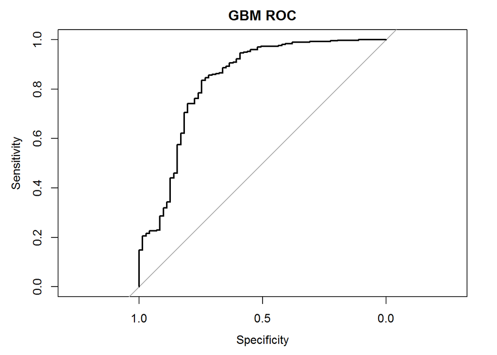

```r
#get probability predictions
probPred <- predict(object=objModel, test[,predictors], type = "prob")

#plot the ROC
gbm.ROC <- roc(predictor=probPred$Yes,
               response=test$Attrition,
               levels=rev(levels(test$Attrition)))
#produce the plot
plot(gbm.ROC,main="GBM ROC")
```

```r
#create the prediction
pred <- ifelse(probPred$Yes > 0.40,"Yes","No")
x <- table(test$Attrition, pred)
# Performance analysis
tn <- x[1]
tp <- x[4]
fp <- x[3]
fn <- x[2]

accuracy <- (tp + tn) / (tp + tn + fp + fn)
misclassification_rate <- 1 - accuracy
recall <- tp / (tp + fn)
precision <- tp / (tp + fp)
null_error_rate <- tn / (tp + tn + fp + fn)
cat(
paste(
paste0("Accuracy:", accuracy),
paste0("Misclassification Rate:", misclassification_rate),
paste0("Recall:", recall),
paste0("Precision:", precision),
paste0("Null Error Rate:", null_error_rate),
sep="\n"
)
)
```

```
## Accuracy:0.81859410430839
## Misclassification Rate:0.18140589569161
## Recall:0.746478873239437
## Precision:0.460869565217391
## Null Error Rate:0.698412698412698
```

As we see here our overall accuracy is lower at ~82% and we are about 50/50 when it comes to our precision or predicting attrition for observation where attrition occured. However, of all the employees that actually left, we predicted them correctly 75% of the time.

Lets unwind some of the details of our model to understand what features are valuable and how the lead to the predictions they do.

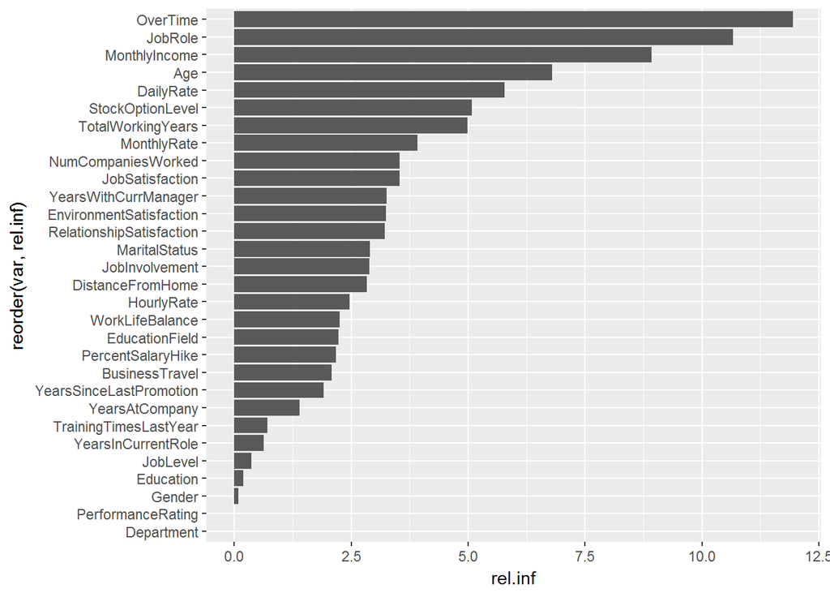

```r
relInf <-summary(objModel, plot = F)
#plot the relative importance
ggplot(relInf, aes(x=reorder(var, rel.inf), y=rel.inf)) +
  geom_bar(stat='identity') +
  coord_flip()
```

Based on this we can see the features that are most influence with predicting attrition are: 1) Overtime 2) Job Role 3) Monthly Income 4) Age 5) Daily Rate

In order to understand how these and other features actually lead to a prediction we can look at a few of the employee’s who left to see how they were labeled by the algorithm and what features led to that prediction.

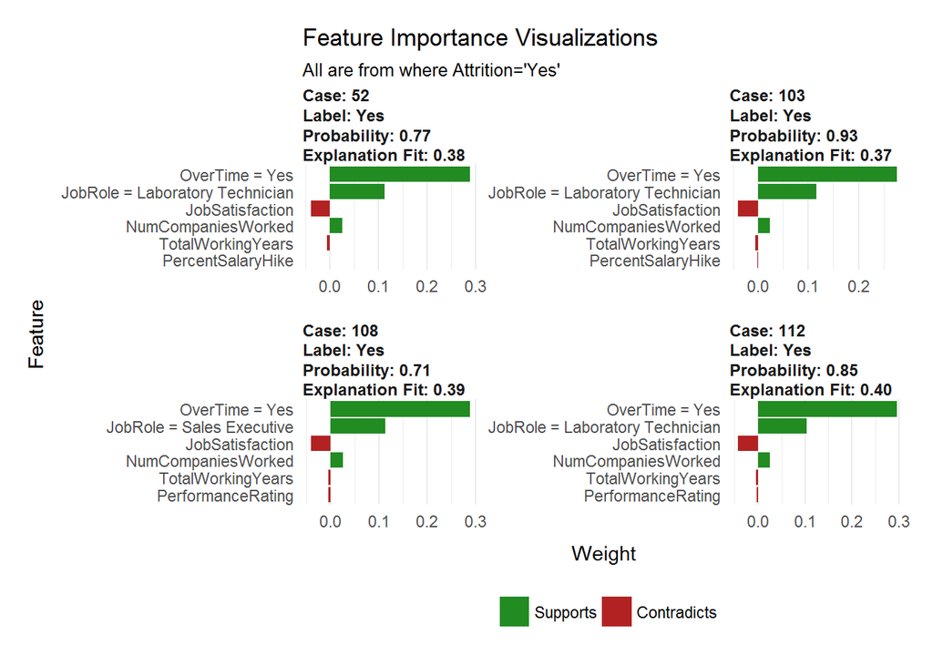

```r
# Run lime() on training set
explainer <- lime::lime(
  as.data.frame(train.both[,-2]),
  model          = objModel,
  bin_continuous = FALSE)

# Run explain() on explainer
explanation <- lime::explain(
  as.data.frame(test[which(test$Attrition =='Yes'),-2][5:8,]),
  explainer    = explainer,
  n_labels     = 1,
  n_features   = 6,
  kernel_width = 0.5)

plot_features(explanation) +
  labs(title = "Feature Importance Visualizations",
       subtitle = "All are from where Attrition='Yes'")
```

These examples show that thing like Lab Technicians & Sales Exec’s that work a over time were all labeled as ‘Yes’ Correctly in the model.

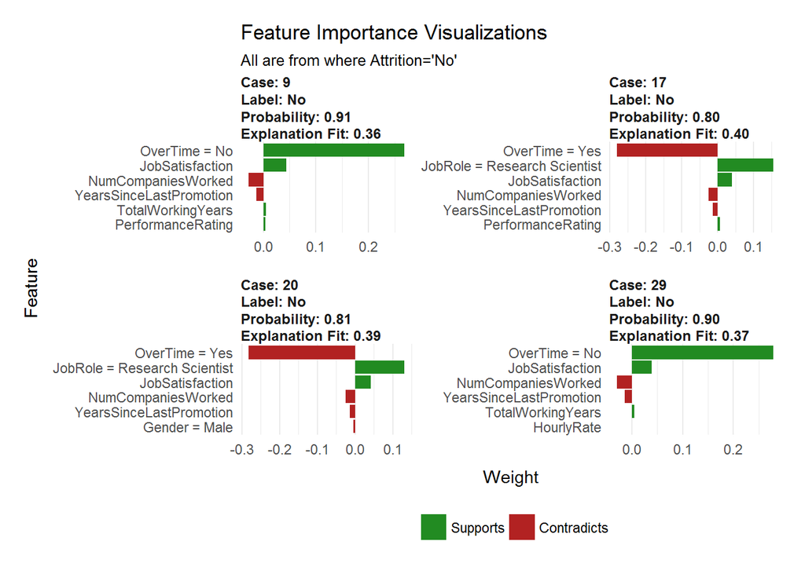

```r
# Run explain() on explainer
explanation <- lime::explain(
  as.data.frame(test[which(test$Attrition =='No'),-2][3:6,]),
  explainer    = explainer,
  n_labels     = 1,
  n_features   = 6,
  kernel_width = 0.5)

plot_features(explanation) +
  labs(title = "Feature Importance Visualizations",
       subtitle = "All are from where Attrition='No'")
```

The examples of the observations that were correctly predicted not to result in attrition it seems that employee’s not working overtime are more likely not to leave, and those that do work overtime and stay work as research scientists or other higher level job roles.

## Targeting at-risk Employees

To better help develop some definition around the employees who actually leave we took some of the top features from our model to try and cluster the employees who left the company to develop an “at-risk” profile.

```r
#clustering customers who left the company using the top 10 features of the model.
dfCluster <- df[which(df$Attrition == 'Yes'), c(as.vector(relInf$var[1:10]))]
#calculate distance between obs
gower_dist <- daisy(dfCluster,
                    metric = "gower")

pam_fit <- pam(gower_dist, diss = TRUE, k = 2)

pam_results <- dfCluster %>%
  mutate(cluster = pam_fit$clustering) %>%
  group_by(cluster) %>%
  do(the_summary = summary(.))

pam_results$the_summary
```

```
## [[1]]
##  OverTime                   JobRole   MonthlyIncome        Age
##  No :  4   Research Scientist   :37   Min.   : 1009   Min.   :18.00
##  Yes:105   Sales Executive      :31   1st Qu.: 2335   1st Qu.:28.00
##            Sales Representative :16   Median : 2853   Median :33.00
##            Laboratory Technician: 9   Mean   : 4923   Mean   :34.59
##            Human Resources      : 5   3rd Qu.: 6134   3rd Qu.:40.00
##            Manager              : 4   Max.   :19859   Max.   :58.00
##            (Other)              : 7
##    DailyRate      StockOptionLevel TotalWorkingYears  MonthlyRate
##  Min.   : 103.0   Min.   :0.0000   Min.   : 0.000    Min.   : 2396
##  1st Qu.: 414.0   1st Qu.:0.0000   1st Qu.: 4.000    1st Qu.: 8450
##  Median : 719.0   Median :0.0000   Median : 7.000    Median :14961
##  Mean   : 737.4   Mean   :0.5229   Mean   : 8.651    Mean   :14625
##  3rd Qu.:1060.0   3rd Qu.:1.0000   3rd Qu.:10.000    3rd Qu.:21534
##  Max.   :1479.0   Max.   :3.0000   Max.   :40.000    Max.   :26999
##
##  NumCompaniesWorked JobSatisfaction    cluster
##  Min.   :0.000      Min.   :1.000   Min.   :1
##  1st Qu.:1.000      1st Qu.:2.000   1st Qu.:1
##  Median :2.000      Median :3.000   Median :1
##  Mean   :3.183      Mean   :2.523   Mean   :1
##  3rd Qu.:5.000      3rd Qu.:3.000   3rd Qu.:1
##  Max.   :9.000      Max.   :4.000   Max.   :1
##
##
## [[2]]
##  OverTime                       JobRole   MonthlyIncome        Age
##  No :106   Laboratory Technician    :53   Min.   : 1081   Min.   :18.00
##  Yes: 22   Sales Executive          :26   1st Qu.: 2406   1st Qu.:26.00
##            Sales Representative     :17   Median : 3460   Median :31.00
##            Research Scientist       :10   Mean   : 4671   Mean   :32.77
##            Healthcare Representative: 7   3rd Qu.: 5346   3rd Qu.:37.00
##            Human Resources          : 7   Max.   :19845   Max.   :58.00
##            (Other)                  : 8
##    DailyRate      StockOptionLevel TotalWorkingYears  MonthlyRate
##  Min.   : 109.0   Min.   :0.0000   Min.   : 0.000    Min.   : 2326
##  1st Qu.: 380.0   1st Qu.:0.0000   1st Qu.: 2.000    1st Qu.: 9213
##  Median : 690.5   Median :0.0000   Median : 6.000    Median :14426
##  Mean   : 761.4   Mean   :0.5312   Mean   : 7.898    Mean   :14503
##  3rd Qu.:1142.2   3rd Qu.:1.0000   3rd Qu.:10.000    3rd Qu.:20687
##  Max.   :1496.0   Max.   :3.0000   Max.   :40.000    Max.   :26956
##
##  NumCompaniesWorked JobSatisfaction    cluster
##  Min.   :0.000      Min.   :1.000   Min.   :2
##  1st Qu.:1.000      1st Qu.:1.000   1st Qu.:2
##  Median :1.000      Median :3.000   Median :2
##  Mean   :2.734      Mean   :2.422   Mean   :2
##  3rd Qu.:5.000      3rd Qu.:3.000   3rd Qu.:2
##  Max.   :9.000      Max.   :4.000   Max.   :2
##
```

It is difficult to cleanly seperate the employees who leave the company into two seperate groups, this does appear to support some of the insights we got from looking at some of the individual classifications.

One group appears to largely be driven by older employees with more work experience who work overtime in largely sales roles. Many of them have worked for multiple companies in the past, but maybe are still farely new to this corporation.

## Conclusion

Depending on the priorities of the company they could proactively target one group by offering different benefits that are considered valuable to the group of interest.